# Boston Public Schools

Derek Sollberger

13 April, 2022

# Loading the Data

Since we are working with an Excel spreadsheet, we will use the `read_xlsx()` command.

```r
df <- read_xlsx("BPS_air_quality.xlsx")

df <- df |>
  filter(Value >= 0) #removing some strange outliers (sensors were broken?)
```

The information is now stored in a *data frame* called `df`.

# Exploring the Data

We can use the `head()` command to get a quick look at the data.

```r
head(df)
```

```
## # A tibble: 6 x 9
##   School    Floor Room  `Live View Senso~ Status `Last Reading  (PS~ Parameter
##   <chr>     <chr> <chr> <chr>             <chr>  <dttm>              <chr>
## 1 Adams El~ 0     2     SAES-0-2CR        Typic~ 2022-01-27 05:06:09 Carbon Dio~
## 2 Adams El~ 0     2     SAES-0-2CR        Typic~ 2022-01-27 05:06:09 Carbon Mon~
## 3 Adams El~ 0     2     SAES-0-2CR        Typic~ 2022-01-27 05:06:09 Particulat~
## 4 Adams El~ 0     2     SAES-0-2CR        Typic~ 2022-01-27 05:06:09 Particulat~
## 5 Adams El~ 0     2     SAES-0-2CR        Typic~ 2022-01-27 05:06:09 Relative H~
## 6 Adams El~ 0     2     SAES-0-2CR        Typic~ 2022-01-27 05:06:09 Temperature
## # ... with 2 more variables: Value <dbl>, Unit <chr>
```

The `str()` gives us the structure of the data frame. Here, we can see which variables are numerical and which are categorical.

```r
str(df)
```

```
## tibble [24,418 x 9] (S3: tbl_df/tbl/data.frame)
##  $ School               : chr [1:24418] "Adams Elementary School" "Adams Elementary School" "Adams Elementary School" "Adams Elementary School" ...
##  $ Floor                : chr [1:24418] "0" "0" "0" "0" ...
##  $ Room                 : chr [1:24418] "2" "2" "2" "2" ...
##  $ Live View Sensor Name: chr [1:24418] "SAES-0-2CR" "SAES-0-2CR" "SAES-0-2CR" "SAES-0-2CR" ...
##  $ Status               : chr [1:24418] "Typical" "Typical" "Typical" "Typical" ...
##  $ Last Reading  (PST)  : POSIXct[1:24418], format: "2022-01-27 05:06:09" "2022-01-27 05:06:09" ...
##  $ Parameter            : chr [1:24418] "Carbon Dioxide" "Carbon Monoxide" "Particulate Pollution 10" "Particulate Pollution 2.5" ...
##  $ Value                : num [1:24418] 443 0.389 2.669 1.992 13.73 ...
##  $ Unit                 : chr [1:24418] "ppm" "ppm" "ug/m3" "ug/m3" ...
```

Source: https://www.bostonpublicschools.org/Page/8810

“Indoor Air Quality sensors have been installed in all BPS classrooms, Nurse’s Offices, and Main Offices, with a roof-top unit installed in every school building to measure outdoor air as a baseline per location.

“Each sensor will record the following IAQ measures:

- Carbon Dioxide (CO2, ppm)
- Carbon Monoxide (CO, ppm)
- Airborne particulates (PM10, ug/m3)
- Airborne Particulates (PM2.5, ug/m3)
- Temperature (T, Fahrenheit)
- Relative Humidity (RH, percent)

# Standard Deviations

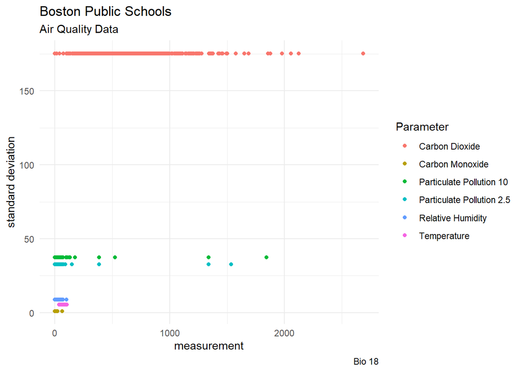

```r
df |>
  group_by(Parameter) |>
  mutate(sd = sd(Value, na.rm = TRUE)) |>
  ungroup() |>
  ggplot() +
  geom_point(aes(x = Value, y = sd, color = Parameter)) +
  labs(title = "Boston Public Schools",
       subtitle = "Air Quality Data",
       caption = "Bio 18",
       x = "measurement",
       y = "standard deviation") +
  theme_minimal()
```

# Range Rule of Thumb

For now (to ease ourselves into learning the concept of the standard deviation), let us use the **range rule of thumb** interval. It is based on classical statistical textbooks that would note how “About 95 percent of data fall within two standard deviations of the mean”
$$(\bar{x} - 2s, \bar{x} + 2s)$$

We need the sample statistics for our data

```r
df |>
  group_by(Parameter) |>
  summarize(xbar = mean(Value, na.rm = TRUE),
            median = median(Value, na.rm = TRUE),
            sd = sd(Value, na.rm = TRUE))
```

```
## # A tibble: 6 x 4
##   Parameter                    xbar  median     sd
##   <chr>                       <dbl>   <dbl>  <dbl>
## 1 Carbon Dioxide            480.    453.    175.
## 2 Carbon Monoxide             0.459   0.365   1.15
## 3 Particulate Pollution 10    4.05    2.46   37.5
## 4 Particulate Pollution 2.5   3.05    1.88   32.7
## 5 Relative Humidity          14.3    12.4     8.90
## 6 Temperature                72.7    72.8     5.42
```

# Boxplots

A **boxplot** tends to be used to quickly show numerical data across a categorical variable.

- the middle line is the median (50th percentile)
- the top and bottom of the rectangles are the 75th and 25th percentile respectively
- the IQR (inter-quartile range) is the difference between the 75th and 25th percentiles
- the “whiskers” are usually drawn out 1.5*IQR beyond the rectangle
- we might consider data beyond the whiskers to be outliers

```r
df |>
  filter(Parameter == "Carbon Dioxide" | Parameter == "Carbon Monoxide") |>
  group_by(Parameter) |>
  summarize(min = round(min(Value, na.rm = TRUE),4),
            q25 = round(quantile(Value, probs = 0.25, na.rm = TRUE),4),
            median = round(median(Value, na.rm = TRUE),4),
            q75 = round(quantile(Value, probs = 0.75, na.rm = TRUE),4),
            max = round(max(Value, na.rm = TRUE),4))
```

```
## # A tibble: 2 x 6
##   Parameter         min     q25  median     q75    max
##   <chr>           <dbl>   <dbl>   <dbl>   <dbl>  <dbl>
## 1 Carbon Dioxide      0 389.    453.    535.    2686
## 2 Carbon Monoxide     0   0.219   0.365   0.574   63.1
```

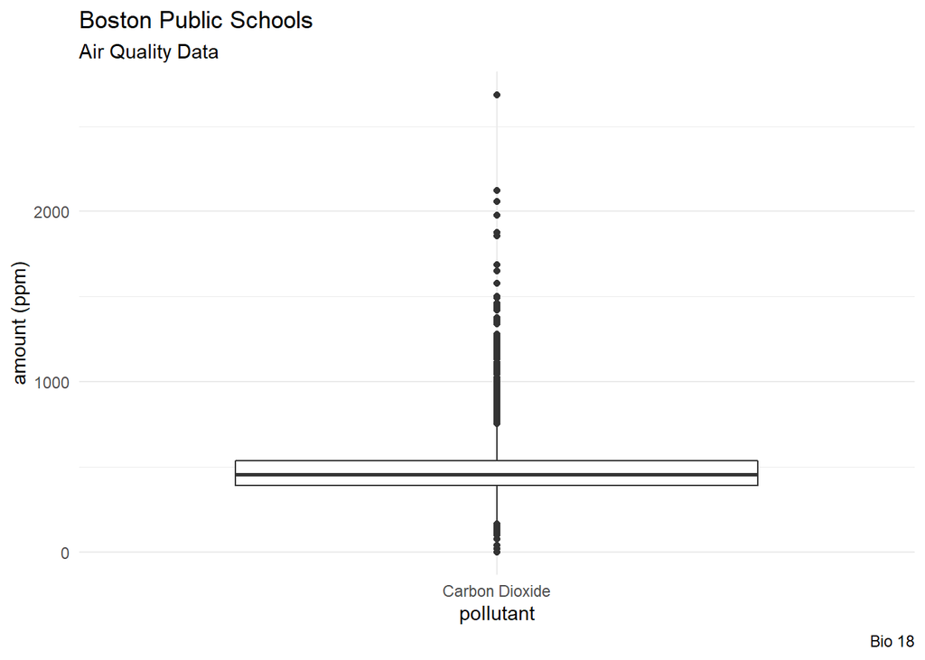

```r
df |>
  filter(Parameter == "Carbon Dioxide") |>
  ggplot() +
  geom_boxplot(aes(x = Parameter, y= Value)) +
  labs(title = "Boston Public Schools",
       subtitle = "Air Quality Data",
       caption = "Bio 18",
       x = "pollutant",
       y = "amount (ppm)") +
  theme_minimal()
```

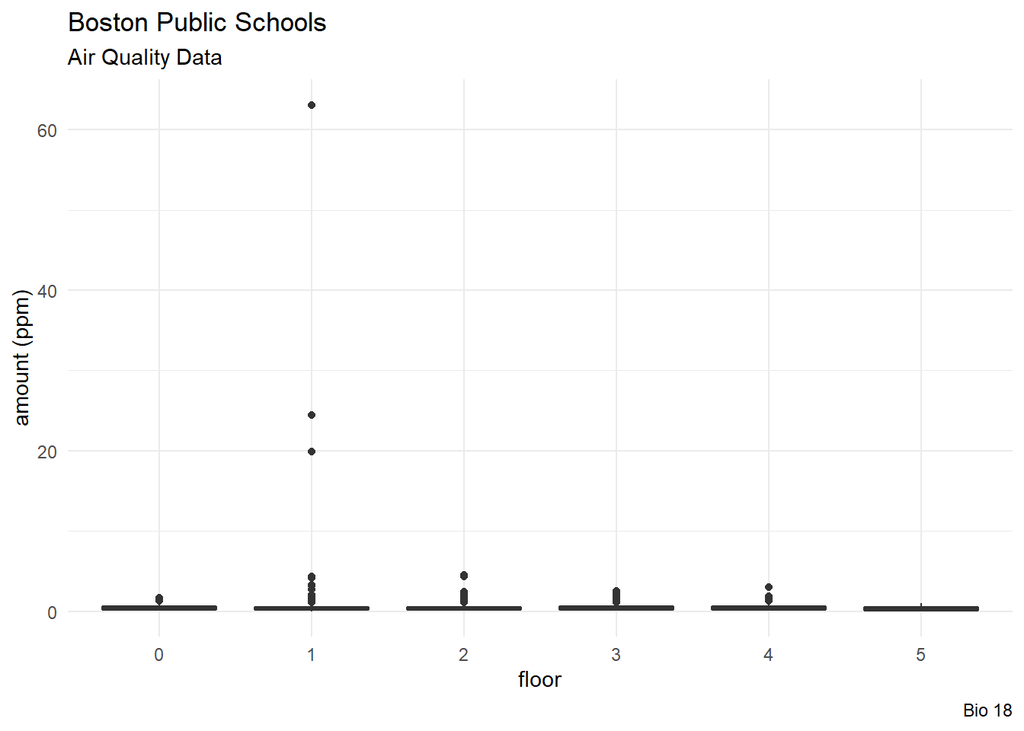

```r
df |>
  filter(Parameter == "Carbon Monoxide") |>
  ggplot() +
  geom_boxplot(aes(x = Floor, y= Value)) +
  labs(title = "Boston Public Schools",
       subtitle = "Air Quality Data",
       caption = "Bio 18",
       x = "floor",
       y = "amount (ppm)") +
  theme_minimal()
```

What is the 95th percentile of carbon monoxide levels?

```r
df |>
  filter(Parameter == "Carbon Dioxide" | Parameter == "Carbon Monoxide") |>
  group_by(Parameter) |>
  summarize(q05 = round(quantile(Value, probs = 0.05, na.rm = TRUE),4),
            q25 = round(quantile(Value, probs = 0.25, na.rm = TRUE),4),
            q50 = round(quantile(Value, probs = 0.50, na.rm = TRUE),4),
            q75 = round(quantile(Value, probs = 0.75, na.rm = TRUE),4),
            q95 = round(quantile(Value, probs = 0.95, na.rm = TRUE),4))
```

```
## # A tibble: 2 x 6
##   Parameter           q05     q25     q50     q75     q95
##   <chr>             <dbl>   <dbl>   <dbl>   <dbl>   <dbl>
## 1 Carbon Dioxide  277.    389.    453.    535.    770.
## 2 Carbon Monoxide   0.088   0.219   0.365   0.574   0.960
```

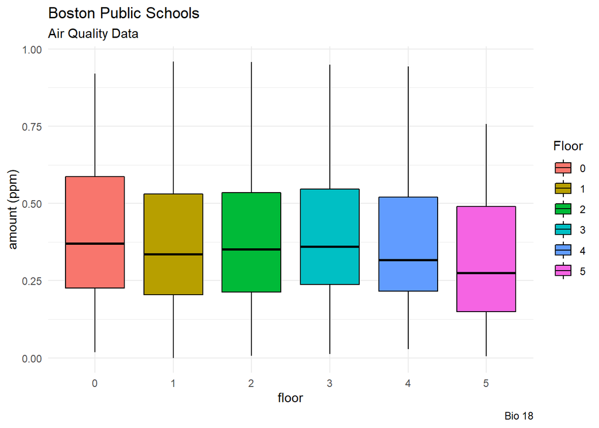

```r
df |>
  filter(Parameter == "Carbon Monoxide") |>
  filter(Value < 0.9605) |>
  ggplot() +
  geom_boxplot(aes(x = Floor, y= Value, fill = Floor),
               color = "black") +
  labs(title = "Boston Public Schools",
       subtitle = "Air Quality Data",
       caption = "Bio 18",
       x = "floor",
       y = "amount (ppm)") +
  theme_minimal()
```

# Building a Correlation Plot

```r
d13_data <- df
# making easier-to-use column names
colnames(d13_data) <- c("school", "floor", "room",
                  "sensor", "status", "read_date_time",
                  "parameter", "value", "units")

# This is too heavy-handed, but I am going to today group the pollution metrics
# by school and day (and average the values?)
# oh, all of the data were from the same day!
d13_data <- d13_data |>
  select(school, parameter, value) |>
  group_by(school, parameter) |>
  mutate(avg_value = mean(value, na.rm = TRUE)) |>
  ungroup() |>
  select(school, parameter, avg_value) |>
  distinct()
head(d13_data)
```

```
## # A tibble: 6 x 3
##   school                  parameter                 avg_value
##   <chr>                   <chr>                         <dbl>
## 1 Adams Elementary School Carbon Dioxide              464.
## 2 Adams Elementary School Carbon Monoxide               0.365
## 3 Adams Elementary School Particulate Pollution 10      2.57
## 4 Adams Elementary School Particulate Pollution 2.5     1.91
## 5 Adams Elementary School Relative Humidity            14.9
## 6 Adams Elementary School Temperature                  73.9
```

```r
# here I wanted each measurement type to have its own column
d13_data_wide <- d13_data |>
  pivot_wider(names_from = parameter,
              values_from = avg_value) |>
  select(-school) #to keep only numerical columns
head(d13_data_wide)
```

```
## # A tibble: 6 x 6
##   `Carbon Dioxide` `Carbon Monoxide` `Particulate Pollution 10` `Particulate Po~
##              <dbl>             <dbl>                      <dbl>            <dbl>
## 1             464.             0.365                       2.57             1.91
## 2             472.             0.592                       4.86             2.93
## 3             494.             0.303                       2.99             2.14
## 4             503.             0.373                       3.46             2.68
## 5             524.             0.565                       2.90             2.27
## 6             511.             0.332                       2.16             1.63
## # ... with 2 more variables: Relative Humidity <dbl>, Temperature <dbl>
```

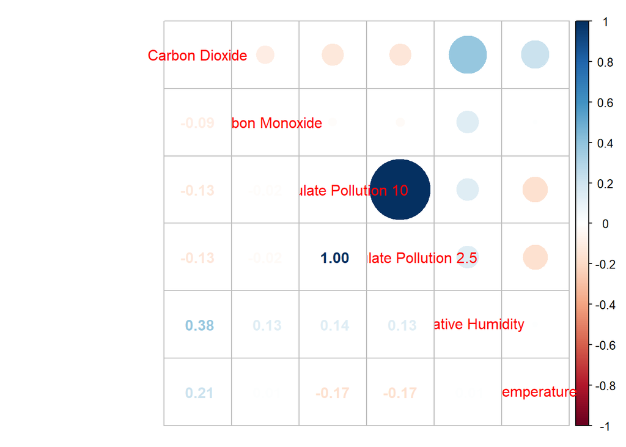

```r
corrplot::corrplot.mixed(cor(d13_data_wide,
                             use = "pairwise.complete.obs"))
```

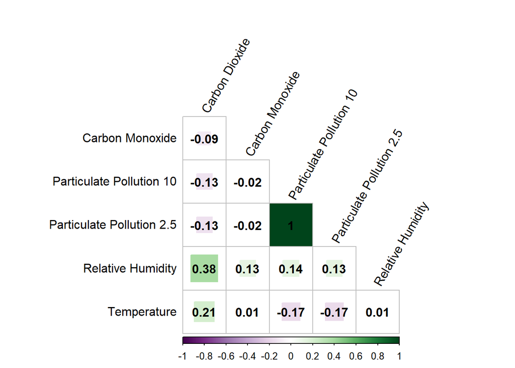

```r
corrplot::corrplot(cor(d13_data_wide, use = "pairwise.complete.obs"),
                   addCoef.col = "black",
                   col = COL2("PRGn"),
                   diag = FALSE,
                   method = "square",
                   # order = "FPC",
                   tl.col = "black",
                   tl.srt = 60, #angled labels
                   type = "lower")
```